# Part II - Exploring the Factors that Affect the Duration of Ford Bike Trips: A Study of Age, Gender, and Subscriber Status.

## by Ayoub RHOUTTAISS

## Investigation Overview

> The aim of this investigation is to identify the factors and characteristics that impact the duration of Ford bike trips, with a focus on the age, gender, and subscriber status of the members.

## Dataset Overview

> The 2019 Ford bike ride dataset is a comprehensive collection of information on over 183215 bike rides taken using Ford bikes. This dataset holds a wealth of information and is comprised of 16 distinct columns, each providing valuable insights into various aspects of the bike rides. The data contained in this dataset was carefully collected and curated, making it a valuable resource for anyone looking to gain a deeper understanding of the Ford bike ride experience. With this dataset, we are able to delve into the details of each bike ride, from :
> - start_time: The time the ride started
> - end_time: The time the ride ended
> - duration_sec: The length of the ride in seconds
> - start_station_id: The id of the station where the ride began
> - end_station_id: The id of the station where the ride ended
> - start_station_name: The id of the station where the ride began
> - end_station_name: The name of the station where the ride ended
> - start_station_latitude: The GPS coordinates of the start station
> - end_station_latitude: The GPS coordinates of the end station
> - bike_id: The id of the bike used for the ride
> - user_type: The type of user who rented the bike
> - member_gender: The gender of the user who rented the bike
> - member_age: The age of the user who rented the bike

## Distribution of Trip Durations

The distribution of trip duration is concentrated between 1 and 200 minutes, and the majority of trips are taken between 5 and 20 minutes.

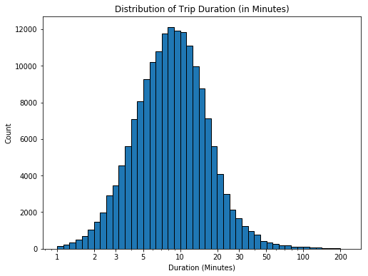

## The correlation between trip duartion and membre age.

There appears to be a correlation between trip duration and member age; as members get older, they tend to take shorter trips.

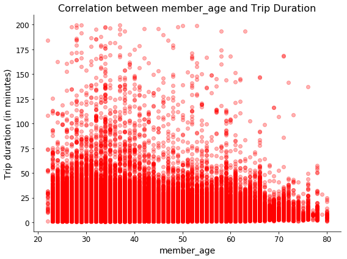

## The correlation between trip duartion and membre gender.

Females tend to take the longest trips, while males surprisingly take the shortest trips.

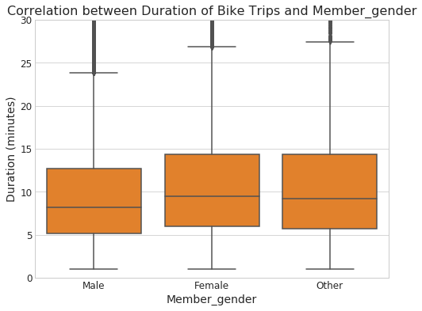